# Statistical analyses of behavioral data from the Eriksen Flanker Task

Supplement: analysis documentation

Louise Bruland Bjerrum

University of Bergen  
louise.bjerrum92@gmail.com

2025-12-29

This report was generated with R version 4.5.1 (2025-06-13 ucrt) and the following package versions:

- tidyverse 2.0.0
- robustlmm 3.3.3
- glmmTMB 1.1.13
- GLMMadaptive 0.9.7
- DHARMa 0.4.7
- performance 0.15.2
- parameters 0.28.2
- correlation 0.8.8
- effectsize 1.0.1
- emmeans 2.0.0
- pubr 0.6.2
- ggsignif 0.6.4

```r
set.seed(123) # set random seed for reproducibility (this is the same seed used in analyses in other work packages related to the overarching project
```

```r
Flanker_data <- read_csv("EFT_dataset.csv", show_col_types = FALSE) %>% # import dataset containing imputed covariates (10% missing) and outcomes (<3% of observations missing)
  select(-1) %>%
  mutate(across(c(Subject, Light, Chronotype_rMEQ), factor)) %>%  # convert character variables ad Subject to factors
  mutate(Light = fct_relevel(Light, "DL", "SWL", "LWL", "BWL"), # make dim light the reference level
         Chronotype_rMEQ = fct_relevel(Chronotype_rMEQ, "Intermediate") # make intermediate chronotype the reference revel as this level is a natural "midpoint" and also the level with most observations
         )
```

```r
Flanker_data_cc <- read_csv("EFT_dataset_sensitivityanalyses.csv", show_col_types = FALSE) %>% # import dataset containing imputed covariates (10% missing) but incomplete outcomes (with NAs (i.e., prior to imputation), < 3 %) to be used in sensitivity analyses of imputed outcomes ("complete-case" analyses)
  select(-1) %>%
  mutate(across(c(Subject, Light, Chronotype_rMEQ), factor)) %>%  # convert character variables and Subject to factors
  mutate(Light = fct_relevel(Light, "DL", "SWL", "LWL", "BWL"), # make dim light the reference level
         Chronotype_rMEQ = fct_relevel(Chronotype_rMEQ, "Intermediate") # make intermediate chronotype the reference revel as this level is a natural "midpoint" and also the level with most observations
         )
```

# 1 Statistical analyses of main outcomes from the Eriksen Flanker Task

## 1.1 Intra-individual reaction time variability in the incompatible (conflict) task condition

**Model specification**

```r
IIVRT_incompatible_mod <- robustlmm::rlmer(IIVRT_incompatible ~ MeanRT_incompatible + Light + TST_IIV + TST_mean + (1 | Subject), data = Flanker_data) # fit robust linear mixed-effects model
```

**Model performance**

| R2_conditional | R2_marginal | ICC | RMSE | Sigma |
| --- | --- | --- | --- | --- |
| 0.8006189 | 0.6737489 | 0.3888722 | 27.20096 | 25.17653 |

**Model parameters**

Robust linear mixed-effects model estimates from analysis of intra-individual reaction time variability in the incompatible flanker task condition

| Parameter | Coefficient | SE | 95% CI | t(136) | p |
| --- | --- | --- | --- | --- | --- |
| Fixed Effects |  |  |  |  |  |
| (Intercept) | -211.78 | 48.24 | (-307.19, -116.37) | -4.39 | < .001 |
| MeanRT incompatible | 0.60 | 0.04 | (0.52, 0.68) | 15.30 | < .001 |
| Light (SWL) | -14.78 | 6.17 | (-26.99, -2.57) | -2.39 | 0.018 |
| Light (LWL) | -8.35 | 6.13 | (-20.48, 3.77) | -1.36 | 0.175 |
| Light (BWL) | -9.18 | 6.33 | (-21.69, 3.33) | -1.45 | 0.149 |
| TST IIV | 0.10 | 0.11 | (-0.13, 0.32) | 0.84 | 0.403 |
| TST mean | 0.05 | 0.11 | (-0.16, 0.26) | 0.50 | 0.619 |
| Random Effects |  |  |  |  |  |
| SD (Intercept: Subject) | 20.08 |  |  |  |  |
| SD (Residual) | 25.18 |  |  |  |  |

Note. The model was fitted using restricted maximum likelihood estimation. N observations = 144. Intra-individual reaction time variability was quantified as the intra-individual standard deviation in reaction time. Abbreviations: BWL = bright white light. CI = confidence interval. LWL = long-wavelength light. RT = reaction time. SE = standard error. SWL = short-wavelength light. TST IIV = Intra-individual variability in total sleep time. TST mean = mean total sleep time.

**Approximated effect sizes**

| Parameter | Cohens_f2_partial | CI | CI_low | CI_high | Interpretation |
| --- | --- | --- | --- | --- | --- |
| MeanRT_incompatible | 1.7222879 | 0.95 | 1.1703623 | 2.3721767 | large |
| LightSWL | 0.0421578 | 0.95 | 0.0008899 | 0.1404587 | small |
| LightLWL | 0.0136410 | 0.95 | 0.0000000 | 0.0813482 | very small |
| LightBWL | 0.0154896 | 0.95 | 0.0000000 | 0.0858157 | very small |
| TST_IIV | 0.0051856 | 0.95 | 0.0000000 | 0.0575806 | very small |
| TST_mean | 0.0018240 | 0.95 | 0.0000000 | 0.0433952 | very small |
| SD (Intercept) | NA | 0.95 | NA | NA | NA |
| SD (Observations) | NA | 0.95 | NA | NA | NA |

**Partial correlations**

```
## Parameter1         |          Parameter2 |    r |       95% CI | t(142) |         p
## -----------------------------------------------------------------------------------
## IIVRT_incompatible | MeanRT_incompatible | 0.73 | [0.65, 0.80] |  12.87 | < .001***
##
## Observations: 144
```

```
## Parameter1         | Parameter2 |  rho |        95% CI |        S |     p
## -------------------------------------------------------------------------
## IIVRT_incompatible |    TST_IIV | 0.09 | [-0.08, 0.25] | 4.55e+05 | 0.310
##
## Observations: 144
```

**Estimated marginal means for the main effect of light**

| Light | emmean | SE | df | asymp.LCL | asymp.UCL |
| --- | --- | --- | --- | --- | --- |
| DL | 135.9557 | 5.587801 | Inf | 125.0038 | 146.9076 |
| SWL | 121.1739 | 5.359609 | Inf | 110.6692 | 131.6785 |
| LWL | 127.6047 | 5.296398 | Inf | 117.2240 | 137.9855 |
| BWL | 126.7744 | 5.657862 | Inf | 115.6852 | 137.8636 |

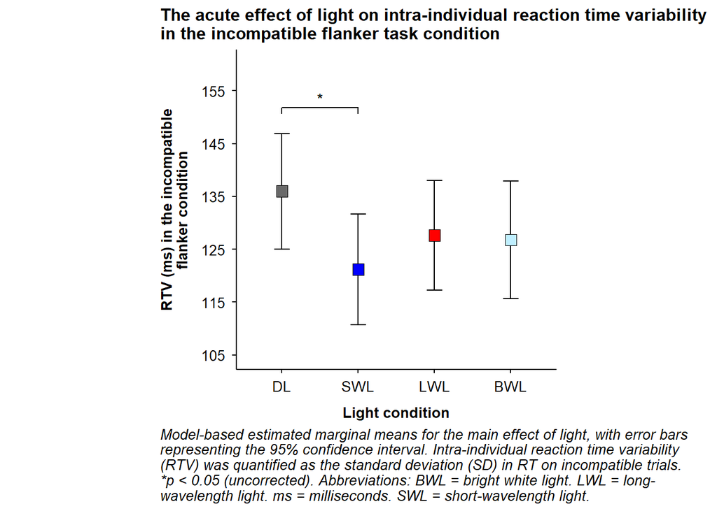

### 1.1.1 Robustness checks and follow-up exploratory analyses

#### 1.1.1.1 Sensitivity analysis of imputed values in outcome variable (“complete-case” analysis)

**Model specification**

```r
IIVRT_incompatible_mod_cc <- robustlmm::rlmer(IIVRT_incompatible ~ MeanRT_incompatible + Light + TST_IIV + TST_mean + (1 | Subject), data = Flanker_data_cc) # fit robust linear mixed-effects model
```

**Model performance**

| R2_conditional | R2_marginal | ICC | RMSE | Sigma |
| --- | --- | --- | --- | --- |
| 0.7892282 | 0.6679247 | 0.365289 | 27.32614 | 25.33727 |

**Model parameters**

Robust linear mixed-effects model estimates from complete-case analysis of intra-individual reaction time variability in the incompatible flanker task condition

| Parameter | Coefficient | SE | 95% CI | t(134) | p |
| --- | --- | --- | --- | --- | --- |
| Fixed Effects |  |  |  |  |  |
| (Intercept) | -200.30 | 47.97 | (-295.19, -105.42) | -4.18 | < .001 |
| MeanRT incompatible | 0.58 | 0.04 | (0.51, 0.66) | 14.83 | < .001 |
| Light (SWL) | -15.71 | 6.24 | (-28.05, -3.38) | -2.52 | 0.013 |
| Light (LWL) | -7.46 | 6.22 | (-19.77, 4.85) | -1.20 | 0.233 |
| Light (BWL) | -9.06 | 6.37 | (-21.65, 3.53) | -1.42 | 0.157 |
| TST IIV | 0.10 | 0.11 | (-0.13, 0.32) | 0.85 | 0.396 |
| TST mean | 0.04 | 0.10 | (-0.16, 0.25) | 0.42 | 0.674 |
| Random Effects |  |  |  |  |  |
| SD (Intercept: Subject) | 19.22 |  |  |  |  |
| SD (Residual) | 25.34 |  |  |  |  |

Note. The model was fitted using restricted maximum likelihood. N observations = 142. Intra-individual reaction time variability was quantified as the intra-individual standard deviation in reaction time. Abbreviations: BWL = bright white light. CI = confidence interval. LWL = long-wavelength light. RT = reaction time. SE = standard error. SWL = short-wavelength light. TST IIV = Intra-individual variability in total sleep time. TSTmean = mean total sleep time.

#### 1.1.1.2 Moderating effect of chronotype

**Model specification**

```r
IIVRT_incompatible_mod_chronotype <- robustlmm::rlmer(IIVRT_incompatible ~ MeanRT_incompatible + Light*Chronotype_rMEQ + TST_IIV + TST_mean + (1 | Subject), data = Flanker_data) # fit robust linear mixed-effects model with light and chronotype in an interaction term
```

**Model performance**

| R2_conditional | R2_marginal | ICC | RMSE | Sigma |
| --- | --- | --- | --- | --- |
| 0.8140496 | 0.6797796 | 0.4193051 | 26.71125 | 24.32795 |

**Model parameters**

Robust linear mixed-effects model estimates from exploratory analysis of intra-individual reaction time variability in the incompatible flanker task condition

| Parameter | Coefficient | SE | 95% CI | t(128) | p |
| --- | --- | --- | --- | --- | --- |
| Fixed Effects |  |  |  |  |  |
| (Intercept) | -210.29 | 49.09 | (-307.43, -113.15) | -4.28 | < .001 |
| MeanRT incompatible | 0.59 | 0.04 | (0.52, 0.67) | 14.95 | < .001 |
| Light (SWL) | -21.06 | 8.51 | (-37.90, -4.21) | -2.47 | 0.015 |
| Light (LWL) | -9.44 | 8.39 | (-26.03, 7.16) | -1.13 | 0.263 |
| Light (BWL) | -14.53 | 8.91 | (-32.16, 3.10) | -1.63 | 0.105 |
| Chronotype rMEQ (Eveningness) | -12.99 | 12.49 | (-37.70, 11.72) | -1.04 | 0.300 |
| Chronotype rMEQ (Morningness) | 2.00 | 14.34 | (-26.38, 30.38) | 0.14 | 0.889 |
| TST IIV | 0.09 | 0.12 | (-0.15, 0.32) | 0.72 | 0.473 |
| TST mean | 0.07 | 0.11 | (-0.15, 0.28) | 0.62 | 0.534 |
| Light (SWL) × Chronotype rMEQ (Eveningness) | 17.81 | 13.75 | (-9.40, 45.02) | 1.29 | 0.198 |
| Light (LWL) × Chronotype rMEQ (Eveningness) | 13.08 | 13.90 | (-14.43, 40.59) | 0.94 | 0.348 |
| Light (BWL) × Chronotype rMEQ (Eveningness) | 20.40 | 14.15 | (-7.60, 48.40) | 1.44 | 0.152 |
| Light (SWL) × Chronotype rMEQ (Morningness) | -0.51 | 16.41 | (-32.97, 31.95) | -0.03 | 0.975 |
| Light (LWL) × Chronotype rMEQ (Morningness) | -24.11 | 16.59 | (-56.93, 8.72) | -1.45 | 0.149 |
| Light (BWL) × Chronotype rMEQ (Morningness) | -8.79 | 16.55 | (-41.53, 23.96) | -0.53 | 0.596 |
| Random Effects |  |  |  |  |  |
| SD (Intercept: Subject) | 20.67 |  |  |  |  |
| SD (Residual) | 24.33 |  |  |  |  |

Note. The model was fitted using restricted maximum likelihood. N observations = 144. Intra-individual reaction time variability was quantified as the intra-individual standard deviation in reaction time. Chronotype was measured with a reduced version of the Morningness-Eveningness Questionnaire (rMEQ). Abbreviations: BWL = bright white light. CI = confidence interval. LWL = long-wavelength light. RT = reaction time. SE = standard error. SWL = short-wavelength light. TST IIV = Intra-individual variability in total sleep time. TSTmean = mean total sleep time.

#### 1.1.1.3 Corrected p-values for the main effect of light on RTV (SD i RT on incompatible trials)

| contrast | estimate | SE | df | z.ratio | p.value |
| --- | --- | --- | --- | --- | --- |
| DL - SWL | 14.7818487 | 6.173344 | Inf | 2.3944637 | 0.0998681 |
| DL - LWL | 8.3509927 | 6.131197 | Inf | 1.3620492 | 0.7333323 |
| DL - BWL | 9.1813759 | 6.325844 | Inf | 1.4514074 | 0.7333323 |
| SWL - LWL | -6.4308560 | 5.924473 | Inf | -1.0854731 | 0.8331366 |
| SWL - BWL | -5.6004728 | 6.239867 | Inf | -0.8975308 | 0.8331366 |
| LWL - BWL | 0.8303832 | 6.196031 | Inf | 0.1340186 | 0.8933879 |

#### 1.1.1.4 The intra-individual coefficient of variability

The intra-individual coefficient of variability is given as:
$$RTsd
\over
RTmean$$
**Model specification**

```r
IICV_incompatible_mod <- robustlmm::rlmer(IICV_incompatible ~ Light + TST_IIV + TST_mean + (1 | Subject), data = Flanker_data) # fit robust linear mixed-effects model
```

**Model performance**

| R2_conditional | R2_marginal | ICC | RMSE | Sigma |
| --- | --- | --- | --- | --- |
| 0.301974 | 0.0209935 | 0.2870058 | 0.0611338 | 0.0650162 |

**Model parameters**

Robust linear mixed-effects model estimates from analysis of intra-individual coefficient of variability in the incompatible flanker task condition

| Parameter | Coefficient | SE | 95% CI | t(137) | p |
| --- | --- | --- | --- | --- | --- |
| Fixed Effects |  |  |  |  |  |
| (Intercept) | 0.31 | 0.10 | (0.12, 0.50) | 3.23 | 0.002 |
| Light (SWL) | -0.02 | 0.02 | (-0.05, 0.01) | -1.19 | 0.237 |
| Light (LWL) | -0.02 | 0.02 | (-0.05, 0.02) | -1.01 | 0.316 |
| Light (BWL) | -0.01 | 0.02 | (-0.04, 0.02) | -0.67 | 0.506 |
| TST IIV | 2.19e-04 | 2.63e-04 | (-3.00e-04, 7.39e-04) | 0.84 | 0.405 |
| TST mean | -1.96e-04 | 2.42e-04 | (-6.74e-04, 2.82e-04) | -0.81 | 0.418 |
| Random Effects |  |  |  |  |  |
| SD (Intercept: Subject) | 0.04 |  |  |  |  |
| SD (Residual) | 0.07 |  |  |  |  |

Note. The model was fitted using restricted maximum likelihood. N observations = 144. The intra-individual coeficient of variability was calculated as the standard deviation in reaction time divided by mean reaction time. Abbreviations: BWL = bright white light. CI = confidence interval. LWL = long-wavelength light. SE = standard error. SWL = short-wavelength light. TST IIV = Intra-individual variability in total sleep time. TSTmean = mean total sleep time.

## 1.2 Intra-individual reaction time variability in the compatible (no conflict) flanker task condition

**Model specification**

```r
IIVRT_compatible_mod <- robustlmm::rlmer(IIVRT_compatible ~ MeanRT_compatible + Light + TST_IIV + TST_mean + (1 | Subject), data = Flanker_data) # fit robust linear mixed-effects model
```

**Model performance**

| R2_conditional | R2_marginal | ICC | RMSE | Sigma |
| --- | --- | --- | --- | --- |
| 0.7137912 | 0.5507555 | 0.3629108 | 20.71255 | 21.76932 |

**Model parameters**

Robust linear mixed-effects model estimates from analysis of intra-individual reaction time variability in the compatible (no conflict) flanker task condition

| Parameter | Coefficient | SE | 95% CI | t(136) | p |
| --- | --- | --- | --- | --- | --- |
| Fixed Effects |  |  |  |  |  |
| (Intercept) | -108.17 | 40.68 | (-188.63, -27.72) | -2.66 | 0.009 |
| MeanRT compatible | 0.54 | 0.04 | (0.45, 0.63) | 12.19 | < .001 |
| Light (SWL) | 1.93 | 5.34 | (-8.62, 12.48) | 0.36 | 0.718 |
| Light (LWL) | 5.16 | 5.31 | (-5.33, 15.65) | 0.97 | 0.332 |
| Light (BWL) | 1.81 | 5.47 | (-9.01, 12.62) | 0.33 | 0.742 |
| TST IIV | 0.03 | 0.10 | (-0.16, 0.22) | 0.28 | 0.783 |
| TST mean | -0.03 | 0.09 | (-0.21, 0.14) | -0.36 | 0.717 |
| Random Effects |  |  |  |  |  |
| SD (Intercept: Subject) | 16.43 |  |  |  |  |
| SD (Residual) | 21.77 |  |  |  |  |

Note. The model was fitted using restricted maximum likelihood. N observations = 144. Intra-individual reaction time variability was quantified as the intra-individual standard deviation in reaction time. Abbreviations: BWL = bright white light. CI = confidence interval. LWL = long-wavelength light. RT = reaction time. SE = standard error. SWL = short-wavelength light. TST IIV = Intra-individual variability in total sleep time. TSTmean = mean total sleep time.

**Approximated effect sizes**

| Parameter | Cohens_f2_partial | CI | CI_low | CI_high | Interpretation |
| --- | --- | --- | --- | --- | --- |
| MeanRT_compatible | 1.0931830 | 0.95 | 0.6977927 | 1.5705552 | large |
| LightSWL | 0.0009621 | 0.95 | 0.0000000 | 0.0371992 | very small |
| LightLWL | 0.0069567 | 0.95 | 0.0000000 | 0.0632706 | very small |
| LightBWL | 0.0008020 | 0.95 | 0.0000000 | 0.0356042 | very small |
| TST_IIV | 0.0005596 | 0.95 | 0.0000000 | 0.0325911 | very small |
| TST_mean | 0.0009710 | 0.95 | 0.0000000 | 0.0372817 | very small |
| SD (Intercept) | NA | 0.95 | NA | NA | NA |
| SD (Observations) | NA | 0.95 | NA | NA | NA |

**Partial correlations**

```
## Parameter1       |        Parameter2 |    r |       95% CI | t(142) |         p
## -------------------------------------------------------------------------------
## IIVRT_compatible | MeanRT_compatible | 0.72 | [0.63, 0.79] |  12.25 | < .001***
##
## Observations: 144
```

```
## Parameter1       | Parameter2 |   rho |        95% CI |        S |     p
## ------------------------------------------------------------------------
## IIVRT_compatible |    TST_IIV | -0.04 | [-0.21, 0.13] | 5.19e+05 | 0.603
##
## Observations: 144
```

**Estimated marginal means for the main effect of light**

| Light | emmean | SE | df | asymp.LCL | asymp.UCL |
| --- | --- | --- | --- | --- | --- |
| DL | 116.3251 | 4.740483 | Inf | 107.0339 | 125.6162 |
| SWL | 118.2553 | 4.546603 | Inf | 109.3442 | 127.1665 |
| LWL | 121.4857 | 4.488328 | Inf | 112.6887 | 130.2827 |
| BWL | 118.1317 | 4.800440 | Inf | 108.7230 | 127.5404 |

[figure not shown]

### 1.2.1 Robustness checks

#### 1.2.1.1 Sensitivity analysis of imputed values in outcome variable (“complete-case” analysis)

**Model specification**

```r
IIVRT_compatible_mod_cc <- robustlmm::rlmer(IIVRT_compatible ~ MeanRT_compatible + Light + TST_IIV + TST_mean + (1 | Subject), data = Flanker_data_cc) # fit robust linear mixed-effects model
```

**Model performance**

| R2_conditional | R2_marginal | ICC | RMSE | Sigma |
| --- | --- | --- | --- | --- |
| 0.7036119 | 0.543632 | 0.3505503 | 20.85981 | 21.87449 |

**Model parameters**

Robust linear mixed-effects model estimates from complete-case analysis of intra-individual reaction time variability in the compatible (no conflict) flanker task condition

| Parameter | Coefficient | SE | 95% CI | t(134) | p |
| --- | --- | --- | --- | --- | --- |
| Fixed Effects |  |  |  |  |  |
| (Intercept) | -106.54 | 40.83 | (-187.30, -25.78) | -2.61 | 0.010 |
| MeanRT compatible | 0.53 | 0.04 | (0.44, 0.62) | 11.90 | < .001 |
| Light (SWL) | 1.26 | 5.38 | (-9.39, 11.90) | 0.23 | 0.816 |
| Light (LWL) | 5.29 | 5.37 | (-5.34, 15.92) | 0.98 | 0.327 |
| Light (BWL) | 1.84 | 5.50 | (-9.03, 12.71) | 0.33 | 0.738 |
| TST IIV | 0.02 | 0.10 | (-0.16, 0.21) | 0.25 | 0.806 |
| TST mean | -0.03 | 0.09 | (-0.20, 0.15) | -0.32 | 0.752 |
| Random Effects |  |  |  |  |  |
| SD (Intercept: Subject) | 16.07 |  |  |  |  |
| SD (Residual) | 21.87 |  |  |  |  |

Note. The model was fitted using restricted maximum likelihood. N observations = 142. Intra-individual reaction time variability was quantified as the intra-individual standard deviation in reaction time. Abbreviations: BWL = bright white light. CI = confidence interval. LWL = long-wavelength light. RT = reaction time. SE = standard error. SWL = short-wavelength light. TST IIV = Intra-individual variability in total sleep time. TSTmean = mean total sleep time.

## 1.3 Conflict effect score

The conflict effect score ([Fan et al 2005](https://doi.org/10.1016/j.neuroimage.2005.02.004)) is given as:
$$RTincompatible - RTcompatible$$
**Model specification**

```r
conflict_effect_mod <- robustlmm::rlmer(Conflict_effect_score ~ Light + TST_IIV + TST_mean + (1 | Subject), data = Flanker_data) # fit robust linear mixed-effects model
```

**Model performance**

| R2_conditional | R2_marginal | ICC | RMSE | Sigma |
| --- | --- | --- | --- | --- |
| 0.6083564 | 0.01960368 | 0.6005253 | 26.79001 | 28.0463 |

**Model parameters**

Robust linear mixed-effects model estimates from analysis of conflict effect scores

| Parameter | Coefficient | SE | 95% CI | t(137) | p |
| --- | --- | --- | --- | --- | --- |
| Fixed Effects |  |  |  |  |  |
| (Intercept) | 159.04 | 58.76 | (42.85, 275.23) | 2.71 | 0.008 |
| Light (SWL) | 2.10 | 6.89 | (-11.53, 15.73) | 0.30 | 0.761 |
| Light (LWL) | 5.75 | 6.87 | (-7.83, 19.33) | 0.84 | 0.404 |
| Light (BWL) | 3.98 | 7.05 | (-9.97, 17.93) | 0.56 | 0.574 |
| TST IIV | 0.04 | 0.16 | (-0.27, 0.35) | 0.25 | 0.803 |
| TST mean | -0.17 | 0.15 | (-0.47, 0.12) | -1.15 | 0.252 |
| Random Effects |  |  |  |  |  |
| SD (Intercept: Subject) | 34.39 |  |  |  |  |
| SD (Residual) | 28.05 |  |  |  |  |

Note. The model was fitted using restricted maximum likelihood. N observations = 144. Conflict effect scores were quantified as mean RT on incompatible trials minus mean RT on compatible trials. Abbreviations: BWL = bright white light. CI = confidence interval. LWL = long-wavelength light. SE = standard error. SWL = short-wavelength light. TST IIV = Intra-individual variability in total sleep time. TSTmean = mean total sleep time.

**Approximated effect sizes**

| Parameter | Cohens_f2_partial | CI | CI_low | CI_high | Interpretation |
| --- | --- | --- | --- | --- | --- |
| LightSWL | 0.0006772 | 0.95 | 0 | 0.0339795 | very small |
| LightLWL | 0.0051220 | 0.95 | 0 | 0.0570703 | very small |
| LightBWL | 0.0023212 | 0.95 | 0 | 0.0458327 | very small |
| TST_IIV | 0.0004572 | 0.95 | 0 | 0.0307911 | very small |
| TST_mean | 0.0096447 | 0.95 | 0 | 0.0706853 | very small |
| SD (Intercept) | NA | 0.95 | NA | NA | NA |
| SD (Observations) | NA | 0.95 | NA | NA | NA |

**Partial correlations**

```
## Parameter1            | Parameter2 |  rho |        95% CI |        S |     p
## ----------------------------------------------------------------------------
## Conflict_effect_score |    TST_IIV | 0.14 | [-0.03, 0.30] | 4.27e+05 | 0.088
##
## Observations: 144
```

**Estimated marginal means for the main effect of light**

| Light | emmean | SE | df | asymp.LCL | asymp.UCL |
| --- | --- | --- | --- | --- | --- |
| DL | 92.59334 | 7.581781 | Inf | 77.73332 | 107.4534 |
| SWL | 94.69326 | 7.347589 | Inf | 80.29225 | 109.0943 |
| LWL | 98.34465 | 7.296883 | Inf | 84.04302 | 112.6463 |
| BWL | 96.57088 | 7.656215 | Inf | 81.56497 | 111.5768 |

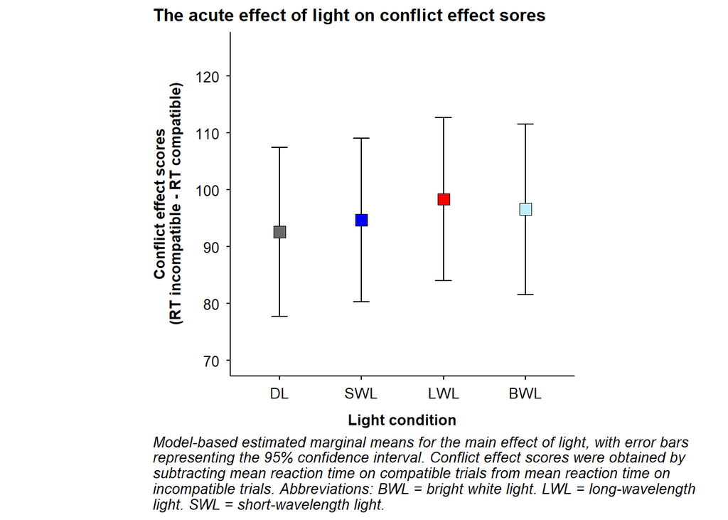

### 1.3.1 Robustness checks

#### 1.3.1.1 Sensitivity analysis of imputed values in outcome variable (“complete-case” analysis)

**Model specification**

```r
conflict_effect_mod_cc <- robustlmm::rlmer(Conflict_effect_score ~ Light + TST_IIV + TST_mean + (1 | Subject), data = Flanker_data_cc) # fit robust linear mixed-effects model
```

**Model performance**

| R2_conditional | R2_marginal | ICC | RMSE | Sigma |
| --- | --- | --- | --- | --- |
| 0.6136069 | 0.01954578 | 0.605904 | 26.80557 | 28.16059 |

**Model parameters**

Robust linear mixed-effects model estimates from complete-case analysis of conflict effect scores

| Parameter | Coefficient | SE | 95% CI | t(135) | p |
| --- | --- | --- | --- | --- | --- |
| Fixed Effects |  |  |  |  |  |
| (Intercept) | 159.05 | 59.49 | (41.39, 276.71) | 2.67 | 0.008 |
| Light (SWL) | 1.42 | 6.95 | (-12.33, 15.16) | 0.20 | 0.839 |
| Light (LWL) | 6.39 | 6.97 | (-7.39, 20.17) | 0.92 | 0.361 |
| Light (BWL) | 3.97 | 7.08 | (-10.04, 17.98) | 0.56 | 0.576 |
| TST IIV | 0.04 | 0.16 | (-0.28, 0.35) | 0.24 | 0.810 |
| TST mean | -0.17 | 0.15 | (-0.47, 0.13) | -1.14 | 0.256 |
| Random Effects |  |  |  |  |  |
| SD (Intercept: Subject) | 34.92 |  |  |  |  |
| SD (Residual) | 28.16 |  |  |  |  |

Note. The model was fitted using restricted maximum likelihood. N observations = 142. Conflict effect scores were quantified as mean RT on incompatible trials minus mean RT on compatible trials. Abbreviations: BWL = bright white light. CI = confidence interval. LWL = long-wavelength light. SE = standard error. SWL = short-wavelength light. TST IIV = Intra-individual variability in total sleep time. TSTmean = mean total sleep time.

# 2 Statistical analyses of secondary outcomes from the Eriksen Flanker Task

## 2.1 Mean reaction time in the incompatible (conflict) flanker task condition

**Model specification**

```r
MeanRT_incompatible_mod <- robustlmm::rlmer(MeanRT_incompatible ~ Light + TST_IIV + TST_mean + (1 | Subject), data = Flanker_data) # fit robust linear mixed-effects model
```

**Model performance**

| R2_conditional | R2_marginal | ICC | RMSE | Sigma |
| --- | --- | --- | --- | --- |
| 0.6334512 | 0.03550118 | 0.6199593 | 45.21771 | 41.34943 |

**Model parameters**

Robust linear mixed-effects model estimates from analysis of mean reaction time in the incompatible flanker task condition

| Parameter | Coefficient | SE | 95% CI | t(137) | p |
| --- | --- | --- | --- | --- | --- |
| Fixed Effects |  |  |  |  |  |
| (Intercept) | 664.67 | 88.53 | (489.61, 839.73) | 7.51 | < .001 |
| Light (SWL) | 7.02 | 10.17 | (-13.08, 27.13) | 0.69 | 0.491 |
| Light (LWL) | -4.44 | 10.13 | (-24.46, 15.59) | -0.44 | 0.662 |
| Light (BWL) | 4.28 | 10.40 | (-16.29, 24.84) | 0.41 | 0.681 |
| TST IIV | -0.06 | 0.24 | (-0.53, 0.41) | -0.26 | 0.793 |
| TST mean | -0.32 | 0.22 | (-0.76, 0.13) | -1.42 | 0.158 |
| Random Effects |  |  |  |  |  |
| SD (Intercept: Subject) | 52.81 |  |  |  |  |
| SD (Residual) | 41.35 |  |  |  |  |

Note. The model was fitted using restricted maximum likelihood. N observations = 144. Abbreviations: BWL = bright white light. CI = confidence interval. LWL = long-wavelength light. SE = standard error. SWL = short-wavelength light. TST IIV = Intra-individual variability in total sleep time. TSTmean = mean total sleep time.

**Partial correlations**

```
## Parameter1          | Parameter2 |  rho |        95% CI |        S |     p
## --------------------------------------------------------------------------
## MeanRT_incompatible |    TST_IIV | 0.09 | [-0.08, 0.26] | 4.52e+05 | 0.271
##
## Observations: 144
```

### 2.1.1 Robustness checks

#### 2.1.1.1 Sensitivity analysis of imputed values in outcome variable (“complete-case” analysis)

**Model specification**

```r
MeanRT_incompatible_mod_cc <- robustlmm::rlmer(MeanRT_incompatible ~ Light + TST_IIV + TST_mean + (1 | Subject), data = Flanker_data_cc) # fit robust linear mixed-effects model
```

**Model performance**

| R2_conditional | R2_marginal | ICC | RMSE | Sigma |
| --- | --- | --- | --- | --- |
| 0.642502 | 0.03824633 | 0.6282853 | 44.84974 | 40.09551 |

**Model parameters**

Robust linear mixed-effects model estimates from complete-case analysis of mean reaction time in the incompatible flanker task condition

| Parameter | Coefficient | SE | 95% CI | t(135) | p |
| --- | --- | --- | --- | --- | --- |
| Fixed Effects |  |  |  |  |  |
| (Intercept) | 672.82 | 86.85 | (501.07, 844.58) | 7.75 | < .001 |
| Light (SWL) | 5.22 | 9.90 | (-14.36, 24.79) | 0.53 | 0.599 |
| Light (LWL) | -1.07 | 9.93 | (-20.70, 18.57) | -0.11 | 0.915 |
| Light (BWL) | 4.49 | 10.09 | (-15.46, 24.43) | 0.44 | 0.657 |
| TST IIV | -0.07 | 0.23 | (-0.52, 0.39) | -0.28 | 0.777 |
| TST mean | -0.34 | 0.22 | (-0.78, 0.09) | -1.55 | 0.124 |
| Random Effects |  |  |  |  |  |
| SD (Intercept: Subject) | 52.13 |  |  |  |  |
| SD (Residual) | 40.10 |  |  |  |  |

Note. The model was fitted using restricted maximum likelihood. N observations = 142. Abbreviations: BWL = bright white light. CI = confidence interval. LWL = long-wavelength light. SE = standard error. SWL = short-wavelength light. TST IIV = Intra-individual variability in total sleep time. TSTmean = mean total sleep time.

## 2.2 Mean reaction time in the compatible (no conflict) flanker task condition

**Model specification**

```r
MeanRT_compatible_mod <- robustlmm::rlmer(MeanRT_compatible ~ Light + TST_IIV + TST_mean + (1 | Subject), data = Flanker_data) # fit robust linear mixed-effects model
```

**Model performance**

| R2_conditional | R2_marginal | ICC | RMSE | Sigma |
| --- | --- | --- | --- | --- |
| 0.4726557 | 0.01786104 | 0.4630655 | 35.88512 | 41.79556 |

**Model parameters**

Robust linear mixed-effects model estimates from analysis of mean reaction time in the compatible (no conflict) flanker task condition

| Parameter | Coefficient | SE | 95% CI | t(137) | p |
| --- | --- | --- | --- | --- | --- |
| Fixed Effects |  |  |  |  |  |
| (Intercept) | 491.23 | 75.24 | (342.45, 640.00) | 6.53 | < .001 |
| Light (SWL) | 8.87 | 10.25 | (-11.40, 29.14) | 0.87 | 0.389 |
| Light (LWL) | -4.85 | 10.20 | (-25.01, 15.32) | -0.48 | 0.635 |
| Light (BWL) | 0.19 | 10.50 | (-20.59, 20.96) | 0.02 | 0.986 |
| TST IIV | -0.09 | 0.20 | (-0.50, 0.31) | -0.45 | 0.656 |
| TST mean | -0.12 | 0.19 | (-0.49, 0.26) | -0.61 | 0.545 |
| Random Effects |  |  |  |  |  |
| SD (Intercept: Subject) | 38.81 |  |  |  |  |
| SD (Residual) | 41.80 |  |  |  |  |

Note. The model was fitted using restricted maximum likelihood. N observations = 144. Abbreviations: BWL = bright white light. CI = confidence interval. LWL = long-wavelength light. SE = standard error. SWL = short-wavelength light. TST IIV = Intra-individual variability in total sleep time. TSTmean = mean total sleep time.

**Partial correlations**

```
## Parameter1        | Parameter2 |       rho |        95% CI |        S |     p
## -----------------------------------------------------------------------------
## MeanRT_compatible |    TST_IIV | -9.16e-03 | [-0.18, 0.16] | 5.02e+05 | 0.913
##
## Observations: 144
```

### 2.2.1 Robustness checks

#### 2.2.1.1 Sensitivity analysis of imputed values in outcome variable (“complete-case” analysis)

**Model specification**

```r
MeanRT_compatible_mod_cc <- robustlmm::rlmer(MeanRT_compatible ~ Light + TST_IIV + TST_mean + (1 | Subject), data = Flanker_data_cc) # fit robust linear mixed-effects model
```

**Model performance**

| R2_conditional | R2_marginal | ICC | RMSE | Sigma |
| --- | --- | --- | --- | --- |
| 0.4589394 | 0.01804227 | 0.448998 | 35.84211 | 41.36004 |

**Model parameters**

Robust linear mixed-effects model estimates from complete-case analysis of mean reaction time in the compatible (no conflict) flanker task condition

| Parameter | Coefficient | SE | 95% CI | t(135) | p |
| --- | --- | --- | --- | --- | --- |
| Fixed Effects |  |  |  |  |  |
| (Intercept) | 502.04 | 73.57 | (356.53, 647.54) | 6.82 | < .001 |
| Light (SWL) | 7.56 | 10.19 | (-12.58, 27.70) | 0.74 | 0.459 |
| Light (LWL) | -2.28 | 10.18 | (-22.42, 17.86) | -0.22 | 0.823 |
| Light (BWL) | 0.17 | 10.39 | (-20.39, 20.73) | 0.02 | 0.987 |
| TST IIV | -0.09 | 0.20 | (-0.48, 0.31) | -0.44 | 0.661 |
| TST mean | -0.14 | 0.19 | (-0.51, 0.22) | -0.78 | 0.439 |
| Random Effects |  |  |  |  |  |
| SD (Intercept: Subject) | 37.34 |  |  |  |  |
| SD (Residual) | 41.36 |  |  |  |  |

Note. The model was fitted using restricted maximum likelihood. N observations = 142. Abbreviations: BWL = bright white light. CI = confidence interval. LWL = long-wavelength light. SE = standard error. SWL = short-wavelength light. TST IIV = Intra-individual variability in total sleep time. TSTmean = mean total sleep time.

## 2.3 Mean accuracy in the incompatible (conflict) flanker task condition

**Model specification**

```r
Accuracy_incompatible_mod <- glmmTMB::glmmTMB(Accuracy_incompatible ~ Light + TST_IIV + TST_mean + (1 | Subject), data = Flanker_data_glmm, family = beta_family(link = "logit")) # fit generalized linear-mixed effects model with a beta probability distribution and logit link function
```

**Model performance**

| AIC | AICc | BIC | R2_conditional | R2_marginal | ICC | RMSE | Sigma |
| --- | --- | --- | --- | --- | --- | --- | --- |
| -468.0575 | -466.9908 | -444.299 | 0.9861257 | 0.0242536 | 0.9857808 | 0.0774665 | 10.33893 |

**Model parameters**

Generalized linear mixed-effects model estimates from analysis of mean accuracy in the incompatible flanker task condition

| Parameter | Coefficient | SE | 95% CI | z | p |
| --- | --- | --- | --- | --- | --- |
| Fixed Effects |  |  |  |  |  |
| (Intercept) | 12.67 | 18.06 | (0.78, 206.95) | 1.78 | 0.075 |
| Light (SWL) | 1.19 | 0.26 | (0.78, 1.81) | 0.79 | 0.428 |
| Light (LWL) | 0.92 | 0.19 | (0.61, 1.38) | -0.42 | 0.677 |
| Light (BWL) | 1.11 | 0.24 | (0.72, 1.71) | 0.46 | 0.644 |
| TST IIV | 1.00 | 4.01e-03 | (0.99, 1.01) | -0.35 | 0.729 |
| TST mean | 1.00 | 3.65e-03 | (0.99, 1.01) | 0.03 | 0.972 |
| Dispersion |  |  |  |  |  |
| (Intercept) | 10.34 |  | (7.56, 14.13) |  |  |
| Random Effects Variances |  |  |  |  |  |
| SD (Intercept: Subject) | 0.70 |  | (0.50, 0.98) |  |  |

Note. The model was fitted with a beta probability distribution and a logit link function. N observations = 144. Coefficients, confidence intervals, and standard errors are exponentiated. Abbreviations: BWL = bright white light. CI = confidence interval. LWL = long-wavelength light. SE = standard error. SWL = short-wavelength light. TST IIV = Intra-individual variability in total sleep time. TSTmean = mean total sleep time.

**Partial correlations**

```
## Parameter1            | Parameter2 |  rho |        95% CI |        S |     p
## ----------------------------------------------------------------------------
## Accuracy_incompatible |    TST_IIV | 0.05 | [-0.12, 0.21] | 4.74e+05 | 0.576
##
## Observations: 144
```

### 2.3.1 Robustness checks

#### 2.3.1.1 Sensitivity analysis of imputed values in outcome variable (“complete-case” analysis)

**Model specification**

```r
Accuracy_incompatible_mod_cc <- glmmTMB::glmmTMB(Accuracy_incompatible ~ Light + TST_IIV + TST_mean + (1 | Subject), data = Flanker_data_cc_glmm, family = beta_family(link = "logit")) # fit generalized linear-mixed effects model with a beta probability distribution and logit link function
```

**Model performance**

| AIC | AICc | BIC | R2_conditional | R2_marginal | ICC | RMSE | Sigma |
| --- | --- | --- | --- | --- | --- | --- | --- |
| -461.8899 | -460.8072 | -438.2433 | 0.986796 | 0.0236734 | 0.9864759 | 0.0777315 | 10.34827 |

**Model parameters**

Generalized linear mixed-effects model estimates from complete-case analysis of mean accuracy in the incompatible flanker task condition

| Parameter | Coefficient | SE | 95% CI | z | p |
| --- | --- | --- | --- | --- | --- |
| Fixed Effects |  |  |  |  |  |
| (Intercept) | 13.65 | 19.73 | (0.80, 232.30) | 1.81 | 0.071 |
| Light (SWL) | 1.20 | 0.26 | (0.79, 1.84) | 0.85 | 0.394 |
| Light (LWL) | 0.92 | 0.20 | (0.61, 1.40) | -0.37 | 0.713 |
| Light (BWL) | 1.09 | 0.24 | (0.71, 1.69) | 0.41 | 0.681 |
| TST IIV | 1.00 | 4.06e-03 | (0.99, 1.01) | -0.35 | 0.726 |
| TST mean | 1.00 | 3.71e-03 | (0.99, 1.01) | -8.84e-03 | 0.993 |
| Dispersion |  |  |  |  |  |
| (Intercept) | 10.35 |  | (7.55, 14.19) |  |  |
| Random Effects Variances |  |  |  |  |  |
| SD (Intercept: Subject) | 0.72 |  | (0.51, 1.01) |  |  |

Note. The model was fitted with a beta probability distribution and a logit link function. N observations = 142. Coefficients, confidence intervals, and standard errors are exponentiated. Abbreviations: BWL = bright white light. CI = confidence interval. LWL = long-wavelength light. SE = standard error. SWL = short-wavelength light. TST IIV = Intra-individual variability in total sleep time. TSTmean = mean total sleep time.

## 2.4 Mean accuracy in the compatible (no conflict) flanker task condition

**Model specification**

```r
Accuracy_compatible_mod <- glmmTMB::glmmTMB(Accuracy_compatible ~ Light + TST_IIV + TST_mean + (1 | Subject), data = Flanker_data_glmm, family = beta_family(link = "logit")) # fit generalized linear-mixed effects model with a beta probability distribution and logit link function
```

**Model performance**

```
## Random effect variances not available. Returned R2 does not account for random effects.
```

| AIC | AICc | BIC | R2_conditional | R2_marginal | RMSE | Sigma |
| --- | --- | --- | --- | --- | --- | --- |
| -1541.149 | -1540.083 | -1517.391 | NA | 0.9029834 | 0.0292072 | 11.58047 |

**Model parameters**

Generalized linear mixed-effects model estimates from analysis of mean accuracy in the compatible (no conflict) flanker task condition

| Parameter | Coefficient | SE | 95% CI | z | p |
| --- | --- | --- | --- | --- | --- |
| Fixed Effects |  |  |  |  |  |
| (Intercept) | 36.18 | 32.31 | (6.29, 208.21) | 4.02 | < .001 |
| Light (SWL) | 1.13 | 0.27 | (0.71, 1.80) | 0.52 | 0.600 |
| Light (LWL) | 0.90 | 0.21 | (0.57, 1.43) | -0.44 | 0.662 |
| Light (BWL) | 0.99 | 0.24 | (0.61, 1.59) | -0.05 | 0.958 |
| TST IIV | 1.00 | 2.58e-03 | (1.00, 1.01) | 0.67 | 0.504 |
| TST mean | 1.00 | 2.17e-03 | (1.00, 1.01) | 0.49 | 0.628 |
| Dispersion |  |  |  |  |  |
| (Intercept) | 11.58 |  | (7.75, 17.30) |  |  |
| Random Effects Variances |  |  |  |  |  |
| SD (Intercept: Subject) | 8.93e-05 |  | (0.00, Inf) |  |  |

Note. The model was fitted with a beta probability distribution and a logit link function. N observations = 144. Coefficients, confidence intervals, and standard errors are exponentiated. Abbreviations: BWL = bright white light. CI = confidence interval. LWL = long-wavelength light. SE = standard error. SWL = short-wavelength light. TST IIV = Intra-individual variability in total sleep time. TSTmean = mean total sleep time.

```r
Accuracy_compatible_mod_2 <- GLMMadaptive::mixed_model(fixed = Accuracy_compatible ~ Light + TST_IIV + TST_mean, random = ~  1 | Subject, data = Flanker_data_glmm, family = beta.fam(), iter_EM = 0) # as the returned conditional R^2 from the original model did not account for random effect variances, extract marginal and conditional R^2 with the GLMMAdaptive package using adaptive gausian quadrature
```

**GLMMAdaptive model performance**

| AIC | AICc | BIC | R2_conditional | R2_marginal | ICC | RMSE | Sigma |
| --- | --- | --- | --- | --- | --- | --- | --- |
| -1540.79 | -1539.723 | -1517.031 | 0.8883806 | 0.3768419 | 0.8208811 | 0.0291979 | 3.383339 |

**Partial correlations**

```
## Parameter1          | Parameter2 |  rho |        95% CI |        S |     p
## --------------------------------------------------------------------------
## Accuracy_compatible |    TST_IIV | 0.08 | [-0.09, 0.25] | 4.57e+05 | 0.329
##
## Observations: 144
```

### 2.4.1 Robustness checks

#### 2.4.1.1 Sensitivity analysis of imputed values in outcome variable (“complete-case” analysis)

**Model specification**

```r
Accuracy_compatible_mod_cc <- glmmTMB::glmmTMB(Accuracy_compatible ~ Light + TST_IIV + TST_mean + (1 | Subject), data = Flanker_data_cc_glmm, family = beta_family(link = "logit")) # fit generalized linear-mixed effects model with a beta probability distribution and logit link function
```

**Model performance**

```
## Random effect variances not available. Returned R2 does not account for random effects.
```

| AIC | AICc | BIC | R2_conditional | R2_marginal | RMSE | Sigma |
| --- | --- | --- | --- | --- | --- | --- |
| -1521.516 | -1520.433 | -1497.869 | NA | 0.9215066 | 0.0293262 | 11.52942 |

**Model parameters**

Generalized linear mixed-effects model estimates from complete-case analysis of mean accuracy in the compatible (no conflict) flanker task condition

| Parameter | Coefficient | SE | 95% CI | z | p |
| --- | --- | --- | --- | --- | --- |
| Fixed Effects |  |  |  |  |  |
| (Intercept) | 32.34 | 29.42 | (5.44, 192.38) | 3.82 | < .001 |
| Light (SWL) | 1.16 | 0.28 | (0.73, 1.85) | 0.63 | 0.531 |
| Light (LWL) | 0.88 | 0.21 | (0.56, 1.40) | -0.53 | 0.595 |
| Light (BWL) | 0.99 | 0.24 | (0.61, 1.59) | -0.04 | 0.964 |
| TST IIV | 1.00 | 2.59e-03 | (1.00, 1.01) | 0.59 | 0.558 |
| TST mean | 1.00 | 2.23e-03 | (1.00, 1.01) | 0.61 | 0.544 |
| Dispersion |  |  |  |  |  |
| (Intercept) | 11.53 |  | (7.70, 17.27) |  |  |
| Random Effects Variances |  |  |  |  |  |
| SD (Intercept: Subject) | 7.38e-05 |  | (0.00, Inf) |  |  |

Note. The model was fitted with a beta probability distribution and a logit link function. N observations = 142. Coefficients, confidence intervals, and standard errors are exponentiated. Abbreviations: BWL = bright white light. CI = confidence interval. LWL = long-wavelength light. SE = standard error. SWL = short-wavelength light. TST IIV = Intra-individual variability in total sleep time. TSTmean = mean total sleep time.

**GLMMadaptive model performance**

```r
Accuracy_compatible_mod_cc_2 <- GLMMadaptive::mixed_model(fixed = Accuracy_compatible ~ Light + TST_IIV + TST_mean, random = ~  1 | Subject, data = Flanker_data_cc_glmm, family = beta.fam(), iter_EM = 0) # as the returned conditional R^2 from the glmmTMB model did not account for random effect variances, fit a generalized linear mixed-effects model using adaptive gaussian quadrature to obtain marginal and conditional R^2
```

| AIC | AICc | BIC | R2_conditional | R2_marginal | ICC | RMSE | Sigma |
| --- | --- | --- | --- | --- | --- | --- | --- |
| -1521.108 | -1520.026 | -1497.462 | 0.896437 | 0.4431734 | 0.8140121 | 0.0293154 | 3.38688 |

# 3 Estimates from “crude” models

*THE ACUTE EFFECTS OF LIGHT ON ERIKSEN FLANKER TASK OUTCOMES, UNADJUSTED FOR POTENTIAL CONFOUNDERS*

## 3.1 Intra-individual reaction time variability in the incompatible (conflict) task condition

**Model specification**

```r
IIVRT_incompatible_mod_crude <- robustlmm::rlmer(IIVRT_incompatible ~ MeanRT_incompatible + Light + (1 | Subject), data = Flanker_data) # fit robust linear mixed-effects model
```

**Model performance**

| R2_conditional | R2_marginal | ICC | RMSE | Sigma |
| --- | --- | --- | --- | --- |
| 0.7978752 | 0.6738853 | 0.3802032 | 27.32537 | 25.13595 |

**Model parameters**

| Parameter | Coefficient | SE | 95% CI | t(138) | p |
| --- | --- | --- | --- | --- | --- |
| Fixed Effects |  |  |  |  |  |
| (Intercept) | -181.10 | 21.47 | (-223.55, -138.65) | -8.44 | < .001 |
| MeanRT incompatible | 0.59 | 0.04 | (0.52, 0.67) | 15.31 | < .001 |
| Light (SWL) | -14.96 | 6.16 | (-27.14, -2.77) | -2.43 | 0.016 |
| Light (LWL) | -7.97 | 6.11 | (-20.04, 4.11) | -1.30 | 0.194 |
| Light (BWL) | -9.41 | 6.31 | (-21.89, 3.07) | -1.49 | 0.138 |
| Random Effects |  |  |  |  |  |
| SD (Intercept: Subject) | 19.69 |  |  |  |  |
| SD (Residual) | 25.14 |  |  |  |  |

Note. The model was fitted using restricted maximum likelihood and are unadjusted for confounders (intra-individual variability in total sleep time and mean total sleep time), except for mean reaction time to account for the typically high correlation among the two. N observations = 144. Intra-individual reaction time variability was quantified as the intra-individual standard deviation in reaction time. Abbreviations: BWL = bright white light. CI = confidence interval. LWL = long-wavelength light. RT = reaction time. SE = standard error. SWL = short-wavelength light.

## 3.2 Intra-individual reaction time variability in the compatible (no conflict) task condition

**Model specification**

```r
IIVRT_compatible_mod_crude <- robustlmm::rlmer(IIVRT_compatible ~ MeanRT_compatible + Light + (1 | Subject), data = Flanker_data) # fit robust linear mixed-effects model
```

**Model performance**

| R2_conditional | R2_marginal | ICC | RMSE | Sigma |
| --- | --- | --- | --- | --- |
| 0.7078057 | 0.5571215 | 0.3402383 | 20.88392 | 21.74952 |

**Model parameters**

Robust linear mixed-effects model estimates from analysis of intra-individual reaction time variability in the compatible (no conflict) flanker task condition

| Parameter | Coefficient | SE | 95% CI | t(138) | p |
| --- | --- | --- | --- | --- | --- |
| Fixed Effects |  |  |  |  |  |
| (Intercept) | -118.63 | 19.72 | (-157.62, -79.64) | -6.02 | < .001 |
| MeanRT compatible | 0.54 | 0.04 | (0.45, 0.62) | 12.33 | < .001 |
| Light (SWL) | 1.99 | 5.33 | (-8.55, 12.52) | 0.37 | 0.709 |
| Light (LWL) | 5.21 | 5.29 | (-5.25, 15.66) | 0.99 | 0.326 |
| Light (BWL) | 1.96 | 5.46 | (-8.84, 12.76) | 0.36 | 0.720 |
| Random Effects |  |  |  |  |  |
| SD (Intercept: Subject) | 15.62 |  |  |  |  |
| SD (Residual) | 21.75 |  |  |  |  |

Note. The model was fitted using restricted maximum likelihood and are unadjusted for confounders (intra-individual variability in total sleep time and mean total sleep time), except for mean reaction time to account for the typically high correlation among the two. N observations = 144. Intra-individual reaction time variability was quantified as the intra-individual standard deviation in reaction time. Abbreviations: BWL = bright white light. CI = confidence interval. LWL = long-wavelength light. RT = reaction time. SE = standard error. SWL = short-wavelength light.

## 3.3 Conflict effect score

**Model specfication**

```r
conflict_effect_mod_crude <- robustlmm::rlmer(Conflict_effect_score ~ Light + (1 | Subject), data = Flanker_data) # fit robust linear mixed-effects model
```

**Model performance**

| R2_conditional | R2_marginal | ICC | RMSE | Sigma |
| --- | --- | --- | --- | --- |
| 0.6205183 | 0.001725451 | 0.6198624 | 26.49538 | 27.61388 |

**Model parameters**

Robust linear mixed-effects model estimates from analysis of conflict effect scores

| Parameter | Coefficient | SE | 95% CI | t(139) | p |
| --- | --- | --- | --- | --- | --- |
| Fixed Effects |  |  |  |  |  |
| (Intercept) | 93.08 | 7.63 | (77.98, 108.17) | 12.19 | < .001 |
| Light (SWL) | 2.10 | 6.79 | (-11.32, 15.53) | 0.31 | 0.757 |
| Light (LWL) | 4.81 | 6.73 | (-8.50, 18.12) | 0.71 | 0.476 |
| Light (BWL) | 4.07 | 6.94 | (-9.64, 17.78) | 0.59 | 0.559 |
| Random Effects |  |  |  |  |  |
| SD (Intercept: Subject) | 35.26 |  |  |  |  |
| SD (Residual) | 27.61 |  |  |  |  |

Note. The model was fitted using restricted maximum likelihood and are unadjusted for confounders (intra-individual variability in total sleep time and mean total sleep time). N observations = 144. Conflict effect scores were quantified as mean RT on incompatible trials minus mean RT on compatible trials. Abbreviations: BWL = bright white light. CI = confidence interval. LWL = long-wavelength light. SE = standard error. SWL = short-wavelength light.

## 3.4 Mean reaction time in the incompatible (conflict) flanker task condition

**Model specification**

```r
MeanRT_incompatible_mod_crude <- robustlmm::rlmer(MeanRT_incompatible ~ Light + (1 | Subject), data = Flanker_data) # fit robust linear mixed-effects model
```

**Model performance**

| R2_conditional | R2_marginal | ICC | RMSE | Sigma |
| --- | --- | --- | --- | --- |
| 0.6569654 | 0.004829887 | 0.6553005 | 44.37356 | 41.81399 |

**Model parameters**

Robust linear mixed-effects model estimates from analysis of mean reaction time in the incompatible flanker task condition

| Parameter | Coefficient | SE | 95% CI | t(139) | p |
| --- | --- | --- | --- | --- | --- |
| Fixed Effects |  |  |  |  |  |
| (Intercept) | 532.78 | 12.10 | (508.85, 556.71) | 44.02 | < .001 |
| Light (SWL) | 6.96 | 10.29 | (-13.37, 27.30) | 0.68 | 0.500 |
| Light (LWL) | -5.73 | 10.20 | (-25.89, 14.43) | -0.56 | 0.575 |
| Light (BWL) | 4.40 | 10.50 | (-16.36, 25.16) | 0.42 | 0.676 |
| Random Effects |  |  |  |  |  |
| SD (Intercept: Subject) | 57.65 |  |  |  |  |
| SD (Residual) | 41.81 |  |  |  |  |

Note. The model was fitted using restricted maximum likelihood and are unadjusted for confounders (intra-individual variability in total sleep time and mean total sleep time). N observations = 144. Abbreviations: BWL = bright white light. CI = confidence interval. LWL = long-wavelength light. RT = reaction time. SE = standard error. SWL = short-wavelength light.

## 3.5 Mean reaction time in the compatible (no conflict) flanker task condition

**Model specification**

```r
MeanRT_compatible_mod_crude <- robustlmm::rlmer(MeanRT_compatible ~ Light + (1 | Subject), data = Flanker_data) # fit robust linear mixed-effects model
```

**Model performance**

[output not shown]

**Model parameters**

| Parameter | Coefficient | SE | 95% CI | t(139) | p |
| --- | --- | --- | --- | --- | --- |
| Fixed Effects |  |  |  |  |  |
| (Intercept) | 437.54 | 9.94 | (417.90, 457.19) | 44.04 | < .001 |
| Light (SWL) | 9.19 | 10.21 | (-11.00, 29.38) | 0.90 | 0.370 |
| Light (LWL) | -5.27 | 10.13 | (-25.30, 14.76) | -0.52 | 0.603 |
| Light (BWL) | 0.34 | 10.45 | (-20.33, 21.01) | 0.03 | 0.974 |
| Random Effects |  |  |  |  |  |
| SD (Intercept: Subject) | 39.86 |  |  |  |  |
| SD (Residual) | 41.64 |  |  |  |  |

Note. The model was fitted using restricted maximum likelihood and are unadjusted for confounders (intra-individual variability in total sleep time and mean total sleep time). N observations = 144. Abbreviations: BWL = bright white light. CI = confidence interval. LWL = long-wavelength light. RT = reaction time. SE = standard error. SWL = short-wavelength light.

## 3.6 Mean accuracy in the incompatible (conflict) flanker task condition

**Model specification**

```r
Accuracy_incompatible_mod_crude <- glmmTMB::glmmTMB(Accuracy_incompatible ~ Light + (1 | Subject), data = Flanker_data_glmm, family = beta_family(link = "logit")) # fit generalized linear-mixed effects model with a beta probability distribution and logit link function
```

**Model performance**

| AIC | AICc | BIC | R2_conditional | R2_marginal | ICC | RMSE | Sigma |
| --- | --- | --- | --- | --- | --- | --- | --- |
| -471.9332 | -471.3201 | -454.1143 | 0.9855293 | 0.02054 | 0.9852259 | 0.0782431 | 10.22957 |

**Model parameters**

Generalized linear mixed-effects model estimates from analysis of mean accuracy in the incompatible flanker task condition

[output not shown]

Note. The model was fitted with a beta probability distribution and a logit link function, and are unadjusted for confounders (intra-individual variability in total sleep time and mean total sleep time). N observations = 144. Coefficients, confidence intervals, and standard errors are exponentiated. Abbreviations: BWL = bright white light. CI = confidence interval. LWL = long-wavelength light. SE = standard error. SWL = short-wavelength light.

## 3.7 Mean accuracy in the compatible (no conflict) flanker task condition

**Model specification**

```r
Accuracy_compatible_mod_crude <- glmmTMB::glmmTMB(Accuracy_compatible ~ Light + (1 | Subject), data = Flanker_data_glmm, family = beta_family(link = "logit")) # fit generalized linear-mixed effects model with a beta probability distribution and logit link function
```

**Model performance**

```
## Random effect variances not available. Returned R2 does not account for random effects.
```

| AIC | AICc | BIC | R2_conditional | R2_marginal | RMSE | Sigma |
| --- | --- | --- | --- | --- | --- | --- |
| -1544.236 | -1543.623 | -1526.417 | NA | 0.8433841 | 0.0292253 | 11.51101 |

**Model parameters**

Generalized linear mixed-effects model estimates from analysis of mean accuracy in the compatible flanker task condition

[output not shown]

Note. The model was fitted with a beta probability distribution and a logit link function, and are unadjusted for confounders (intra-individual variability in total sleep time and mean total sleep time). N observations = 144. Coefficients, confidence intervals, and standard errors are exponentiated. Abbreviations: BWL = bright white light. CI = confidence interval. LWL = long-wavelength light. SE = standard error. SWL = short-wavelength light.